# Final Project - Twitter

Kushagra Sen, DeepakRao Bandhakavi, Akhil Menon

2/24/2020

The process started with extracting tweets from twitter using Twitter API. The tweets are collected by filtering from frequently used hashtags like #iPhone11, #iPhone11Pro etc. and famous twitter handles such as the Apple CEO Tim Cook.

Post collection, data is cleaned to make it devoid of duplicates, punctuation flaws, numbers, URL’s etc which cleared the ground for data analysis.

```r
final_tweets <- read.csv("https://drive.google.com/uc?export=download&id=1kOlxzs8Bq9WzXl8UlZDD8mOrTE9pyq6s")
head(final_tweets,5)
```

```
##   Sno     user_id created_at     screen_0me
## 1  23 1.17415e+18  1/21/2020 Kitty_Litter37
## 2  31 8.67593e+17  1/21/2020 whitestonedome
## 3  42 8.67593e+17  1/21/2020 whitestonedome
## 4 106 8.67593e+17  1/21/2020 whitestonedome
## 5 114 8.67593e+17  1/21/2020 whitestonedome
##                                                                                                                                                                                                                                                                 text
## 1                                                                                    #filters #iphone11 #dope #shit #WednesdayMotivation #podcasts PEOPLE HAVE DROPPED SOME DOPE EPISODES #today CANT WAIT TO WATCH THEM #ALL #UnityDay2019 #INVINCIBLE :/uFlnQJFIiF
## 2                    Apple iPhone 11 Pro Max display repair prices, and the best screen protectors to avoid them :/ilBioTBSD6\n#iPhone11 #iPhone11ProMax #screenprotector\n\nThe Best Protection for your device #WhitestoneDomeGlass \n30% off now :/q1TZXAcQlf :/
## 3 The best iPhone 11 Pro screen protectors to stay scratch-free and unblemished :/m4ZeiIFH5u via @DigitalTrends \n#iphone11 #iPhone11Pro #iPhone11ProMax #screenprotector #WhitestoneDomeGlass\n\nKeep your screen scratch-free for good!\n:/q1TZXAcQlf :/aB9ijovZDY
## 4         Install It Right!  iPhone 11 Whitestone Dome Glass Screen Protector Install :/xcP3usb3Cc #WhitestoneDomeGlass\n#iPhone11 #iPhone11ProMax #iPhone11Pro #screenprotector \n\nPROTECT YOUR DEVICE WITH THE DOME GLASS 😍\n:/q1TZXAcQlf :/iFFO50Lzoy
## 5                                                       iPhone 11 Pro Whitestone Dome NEW Installation Process How To :/BYNmPOlq42 #WhitestoneDomeGlass \n#iPhone11 #iPhone11Pro #iPhone11ProMax \n\nPROTECT YOUR DEVICE WITH DOME GLASS \n:/q1TZXAcQlf :/wufXa66Mzj
##               source is_retweet favorite_count retweet_count reply_count
## 1 Twitter for iPhone      FALSE              0             0           0
## 2             Buffer      FALSE              0             0           0
```

[output cut: 27 more lines]

We have date written in a format MM/DD/YYYY and we are de-limiting it so that we can evaluate the monthly and yearly trends.

```r
final_tweets <- final_tweets %>%
  separate(created_at
           , into = c("Month", "Date", "Year"), sep = "/")
```

### **Step 1:** Data Visualization

**This graph shows the frequency of tweets based on the Source attribute**

```r
src_df <- table(final_tweets$source)
str(src_df)
```

```
##  'table' int [1:74(1d)] 5 4 18 1 3 18 4 1130 16 4 ...
##  - attr(*, "dimnames")=List of 1
##   ..$ : chr [1:74] "AgoraPulse Manager" "Apple Educate Retweet" "Appleinsider.com " "bitcoinagile" ...
```

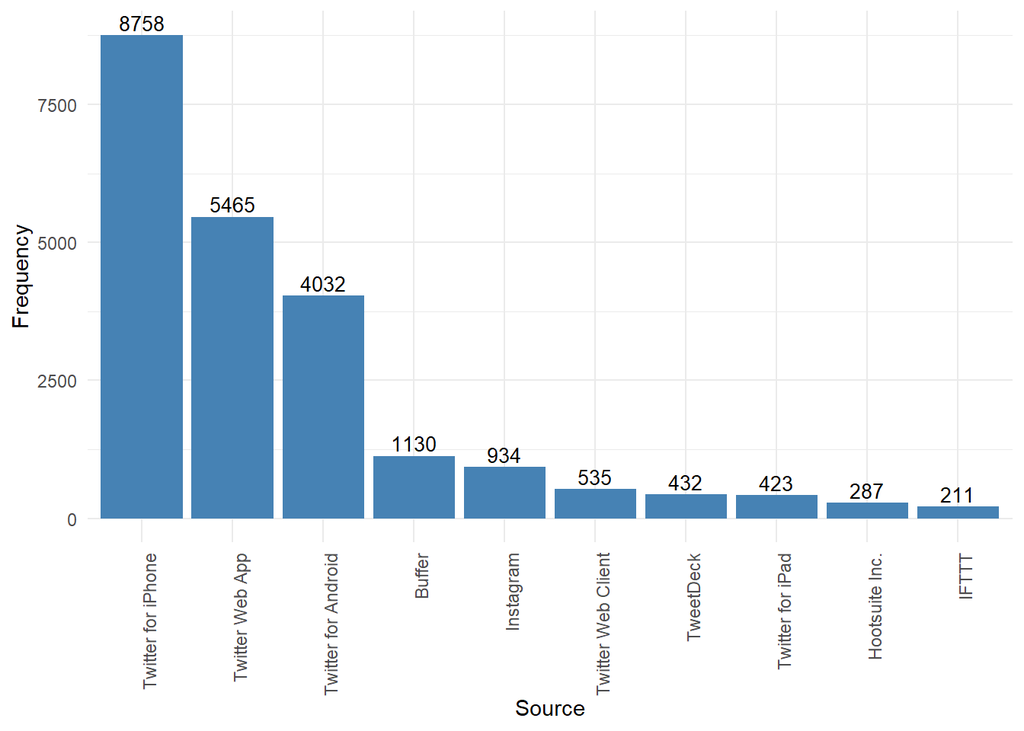

```r
w <- as.data.frame(table(final_tweets$source))
w <- w[order(-w$Freq),]
names(w) <- c("Source","Frequency")
ggplot(data=w[0:10,], aes(x=reorder(Source,-Frequency), y=Frequency)) +
  geom_bar(stat="identity", fill="steelblue")+
  geom_text(aes(label=Frequency), vjust=-0.3, size=3.5)+
  theme_minimal()+theme(axis.text.x = element_text(angle = 90, hjust = 1)) +xlab("Source")
```

**This graph shows the frequency of tweets based on the user location**

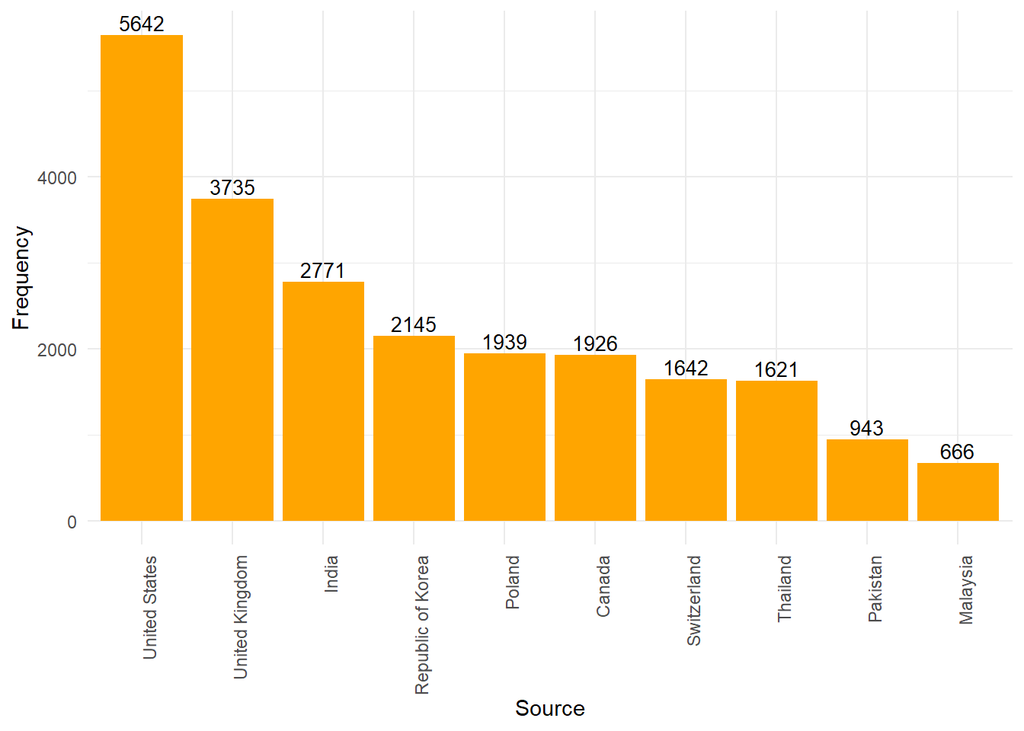

```r
w <- as.data.frame(table(final_tweets$country ))
w <- w[order(-w$Freq),]
names(w) <- c("Country","Frequency")

ggplot(data=w[0:10,], aes(x=reorder(Country,-Frequency), y=Frequency)) +
  geom_bar(stat="identity", fill="orange")+
  geom_text(aes(label=Frequency), vjust=-0.3, size=3.5)+
  theme_minimal()+theme(axis.text.x = element_text(angle = 90, hjust = 1)) +xlab("Source")
```

**Here we can see the Day-to-Day trend of tweets regarding iPhone 11 series**

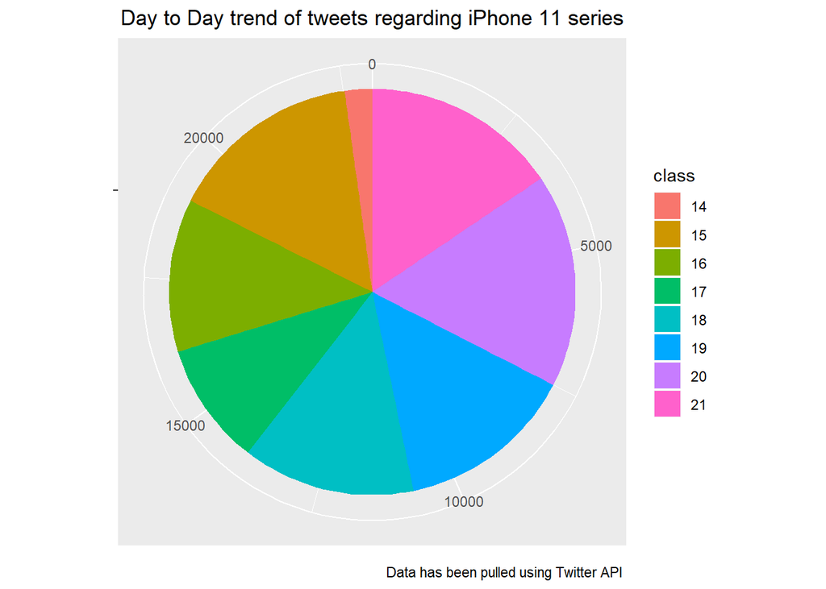

```r
pie <- ggplot(final_tweets, aes(x = "", fill = factor(Date))) +
  geom_bar(width = 1) +
  theme(axis.line = element_blank(),
        plot.title = element_text(hjust=0.5)) +
  labs(fill="class",
       x=NULL,
       y=NULL,
       title="Day to Day trend of tweets regarding iPhone 11 series",
       caption="Data has been pulled using Twitter API ")
pie + coord_polar(theta = "y", start=0)
```

### **Step 2:** Sentiment Analysis

**1. Cleaning the special characters and links from the tweets:** Since the data obtained from twitter is random text with a lot of irregularities and irrelevant content, data had to be made ready for further analysis. The tweets consisted of duplicate tweets, additional website/blog links, Punctuation marks, irregular font and text, repeated words.

```r
total_text <- rbind(final_tweets)
total_text$text = gsub("&amp", "", total_text$text)
total_text$text = gsub("&amp", "", total_text$text)
total_text$text = gsub("(RT|via)((?:\\b\\W*@\\w+)+)", "", total_text$text)
total_text$text = gsub("@\\w+", "", total_text$text)
total_text$text = gsub("[[:punct:]]", "", total_text$text)
total_text$text = gsub("[[:digit:]]", "", total_text$text)
total_text$text = gsub("http\\w+", "", total_text$text)
total_text$text = gsub("[ \t]{2,}", "", total_text$text)
total_text$text = gsub("^\\s+|\\s+$", "", total_text$text)
```

Frequently occuring but common words which can be considered as stop words

```r
df <- total_text %>% mutate(Text = str_replace_all(text, "(<br />)+", " "))
tokens <- df %>% unnest_tokens(output = word, input = Text)
tokens %>%  dplyr::count(word, sort = TRUE)
```

```
## # A tibble: 31,386 x 2
##    word          n
##    <chr>     <int>
##  1 iphone    12444
##  2 the       11503
##  3 to         9781
##  4 my         7407
##  5 i          7071
##  6 iphonepro  6823
##  7 a          6519
##  8 and        6183
##  9 for        5410
## 10 apple      5136
## # ... with 31,376 more rows
```

As most of the words are stopwords, we should remove them.

```r
get_stopwords()
```

```
## # A tibble: 175 x 2
##    word      lexicon
##    <chr>     <chr>
##  1 i         snowball
##  2 me        snowball
##  3 my        snowball
##  4 myself    snowball
##  5 we        snowball
##  6 our       snowball
##  7 ours      snowball
##  8 ourselves snowball
##  9 you       snowball
## 10 your      snowball
## # ... with 165 more rows
```

```r
cleaned_tokens <- tokens %>%  anti_join(get_stopwords())
nums <- cleaned_tokens %>% filter(str_detect(word, "^[0-9]")) %>% select(word) %>% unique()
cleaned_tokens <- cleaned_tokens %>%   anti_join(nums, by = "word")
```

After removing the stop words, we get:

```r
cleaned_tokens %>%  dplyr::count(word, sort = TRUE)
```

```
## # A tibble: 31,261 x 2
##    word             n
##    <chr>        <int>
##  1 iphone       12444
##  2 iphonepro     6823
##  3 apple         5136
##  4 iphonepromax  3349
##  5 new           3190
##  6 max           2564
##  7 care          2384
##  8 phone         1693
##  9 gb            1686
## 10 like          1451
## # ... with 31,251 more rows
```

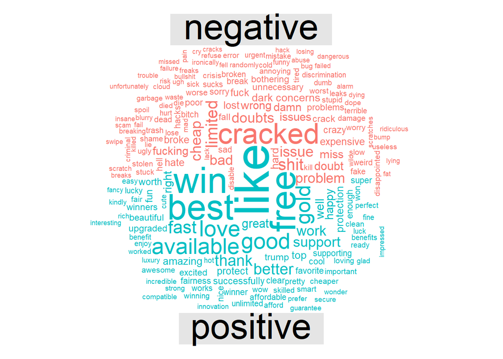

```r
tokens %>%
  inner_join(get_sentiments("bing")) %>%
  count(word, sentiment, sort=TRUE) %>%
  acast(word ~ sentiment, value.var="n", fill=0) %>%
  comparison.cloud(colors=c("#F8766D", "#00BFC4"), max.words=200)
```

```r
sentiments <- tokens %>%
  inner_join(get_sentiments("nrc")) %>%
  count(word, sentiment, sort=TRUE)
```

**3. This graph shows the frequency of various sentiments gathered through these tweets**

```r
sentiments <- tokens %>%
  inner_join(get_sentiments("nrc")) %>%
  count(word, sentiment, sort=TRUE)
```

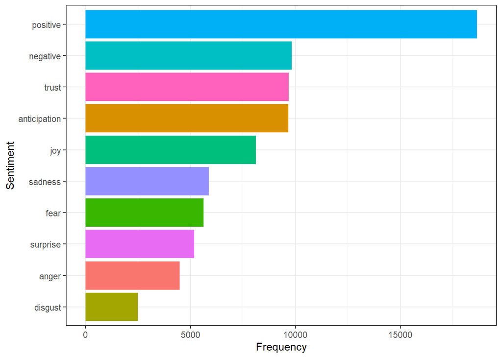

```r
ggplot(data=sentiments, aes(x=reorder(sentiment, n, sum), y=n)) +
  geom_bar(stat="identity", aes(fill=sentiment), show.legend=FALSE) +
  labs(x="Sentiment", y="Frequency") +
  theme_bw() +
  coord_flip()
```

**4. This graph shows the Top 10 frequent terms for each sentiment**

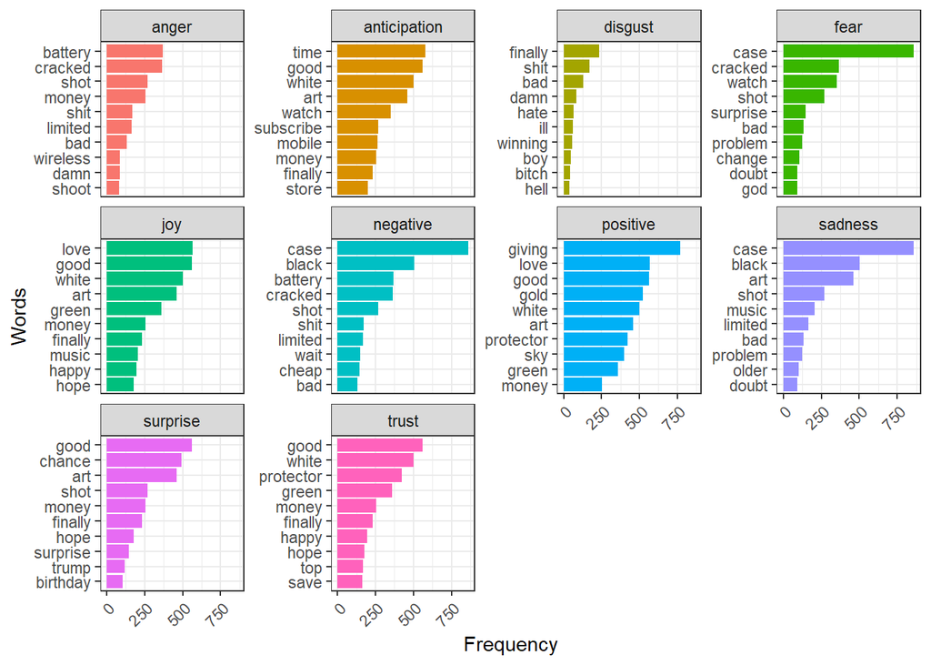

```r
sentiments %>%
  group_by(sentiment) %>%
  arrange(desc(n)) %>%
  slice(1:10) %>%
  ggplot(aes(x=reorder(word, n), y=n)) +
  geom_col(aes(fill=sentiment), show.legend=FALSE) +
  theme_bw() +
  theme(axis.text.x=element_text(angle=45, hjust=1)) +
  facet_wrap(~sentiment, scales="free_y") +
  labs(y="Frequency", x="Words") +
  coord_flip()
```

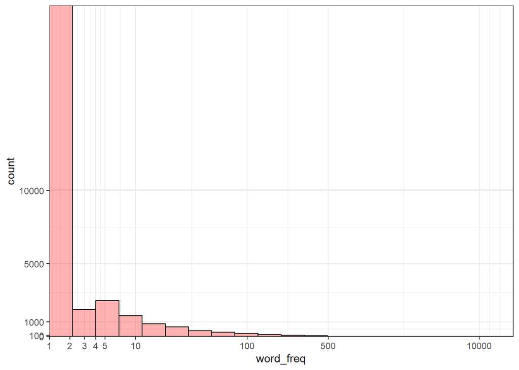

```r
cleaned_tokens %>%   dplyr::count(word, sort = T) %>%  dplyr::rename(word_freq = n) %>%
  ggplot(aes(x=word_freq)) +  geom_histogram(aes(y=..count..), color="black", fill="red", alpha=0.3, bins=20) +  scale_x_continuous(breaks=c(0:5,10,100,500,10e3), trans="log1p", expand=c(0,0)) +  scale_y_continuous(breaks=c(0,100,1000,5e3,10e3,5e4,10e4,4e4), expand=c(0,0)) +  theme_bw()
```

So it makes sense to remove rare words to improve the performance of text analytics. Let’s remove words that have less than 10 appearances in our collection:

```r
rare <- cleaned_tokens %>%   dplyr::count(word) %>%  filter(n<10) %>%  select(word) %>% unique()
cleaned_tokens <- cleaned_tokens %>%   anti_join(rare, by = "word")
length(unique(cleaned_tokens$word))
```

```
## [1] 3304
```

**6. Word Cloud of frequently occuring words**

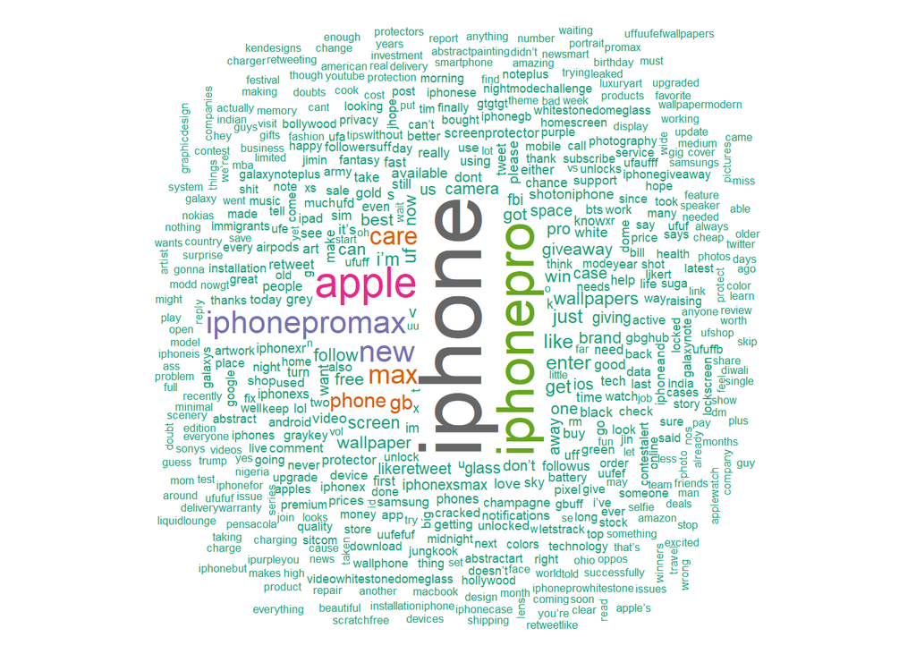

```r
pal <- brewer.pal(8,"Dark2")
cleaned_tokens %>%   dplyr::count(word) %>%  with(wordcloud(word, n, random.order = FALSE, max.words =500, colors=pal))
```

**7. Getting Sentiments from “nrc”,“afinn” and “bing”**

```r
get_sentiments("nrc")
```

```
## # A tibble: 13,901 x 2
##    word        sentiment
##    <chr>       <chr>
##  1 abacus      trust
##  2 abandon     fear
##  3 abandon     negative
##  4 abandon     sadness
##  5 abandoned   anger
##  6 abandoned   fear
##  7 abandoned   negative
##  8 abandoned   sadness
##  9 abandonment anger
## 10 abandonment fear
## # ... with 13,891 more rows
```

```r
get_sentiments("afinn")
```

```
## # A tibble: 2,477 x 2
##    word       value
##    <chr>      <dbl>
##  1 abandon       -2
##  2 abandoned     -2
##  3 abandons      -2
##  4 abducted      -2
##  5 abduction     -2
##  6 abductions    -2
##  7 abhor         -3
##  8 abhorred      -3
##  9 abhorrent     -3
## 10 abhors        -3
## # ... with 2,467 more rows
```

```r
get_sentiments("bing")
```

```
## # A tibble: 6,786 x 2
##    word        sentiment
##    <chr>       <chr>
##  1 2-faces     negative
##  2 abnormal    negative
##  3 abolish     negative
##  4 abominable  negative
##  5 abominably  negative
##  6 abominate   negative
##  7 abomination negative
##  8 abort       negative
##  9 aborted     negative
## 10 aborts      negative
## # ... with 6,776 more rows
```

```r
sent_reviews = cleaned_tokens %>%
  left_join(get_sentiments("nrc")) %>%
  rename(nrc = sentiment) %>%
  left_join(get_sentiments("bing")) %>%
  rename(bing = sentiment) %>%
  left_join(get_sentiments("afinn")) %>%
  rename(afinn = value)
head(sent_reviews,5)
```

```
##   Sno     user_id Month Date Year     screen_0me
## 1  23 1.17415e+18     1   21 2020 Kitty_Litter37
## 2  23 1.17415e+18     1   21 2020 Kitty_Litter37
## 3  23 1.17415e+18     1   21 2020 Kitty_Litter37
## 4  23 1.17415e+18     1   21 2020 Kitty_Litter37
## 5  23 1.17415e+18     1   21 2020 Kitty_Litter37
##                                                                                                                                                            text
## 1 filters iphone dope shit WednesdayMotivation podcasts PEOPLE HAVE DROPPED SOME DOPE EPISODES today CANT WAIT TO WATCH THEM ALL UnityDay INVINCIBLE uFlnQJFIiF
## 2 filters iphone dope shit WednesdayMotivation podcasts PEOPLE HAVE DROPPED SOME DOPE EPISODES today CANT WAIT TO WATCH THEM ALL UnityDay INVINCIBLE uFlnQJFIiF
## 3 filters iphone dope shit WednesdayMotivation podcasts PEOPLE HAVE DROPPED SOME DOPE EPISODES today CANT WAIT TO WATCH THEM ALL UnityDay INVINCIBLE uFlnQJFIiF
## 4 filters iphone dope shit WednesdayMotivation podcasts PEOPLE HAVE DROPPED SOME DOPE EPISODES today CANT WAIT TO WATCH THEM ALL UnityDay INVINCIBLE uFlnQJFIiF
## 5 filters iphone dope shit WednesdayMotivation podcasts PEOPLE HAVE DROPPED SOME DOPE EPISODES today CANT WAIT TO WATCH THEM ALL UnityDay INVINCIBLE uFlnQJFIiF
##               source is_retweet favorite_count retweet_count reply_count
## 1 Twitter for iPhone      FALSE              0             0           0
## 2 Twitter for iPhone      FALSE              0             0           0
```

[output cut: 27 more lines]

**8. Most common positive and negative words**

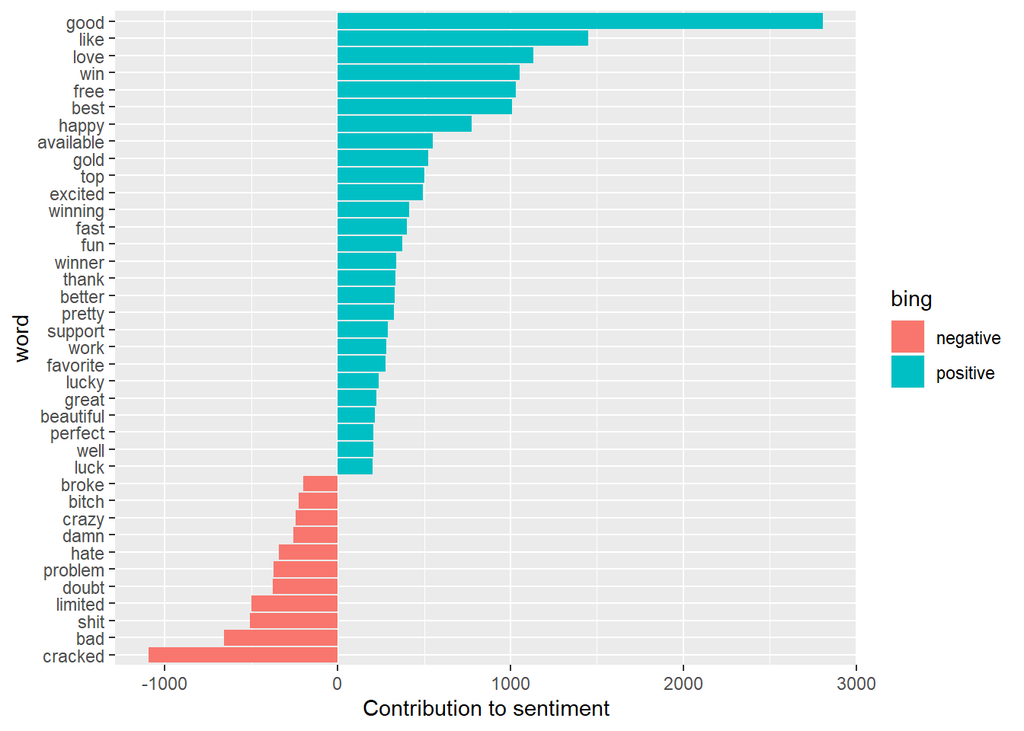

```r
bing_word_counts <- sent_reviews %>%  filter(!is.na(bing)) %>%  dplyr::count(word, bing, sort = TRUE)

bing_word_counts %>%  filter(n > 200) %>%  mutate(n = ifelse(bing == "negative", -n, n)) %>%
  mutate(word = reorder(word, n)) %>%  ggplot(aes(word, n, fill = bing)) +  geom_col() +  coord_flip() +  labs(y = "Contribution to sentiment")
```

**9. Now, tokenizing by n-gram**

```r
bigrams <- tokens %>%  unnest_tokens(bigram, text, token = "ngrams", n = 2)
bigrams %>%  dplyr::count(bigram, sort = TRUE)
```

```
## # A tibble: 149,834 x 2
##    bigram               n
##    <chr>            <int>
##  1 iphonepro max    37836
##  2 to enter         23709
##  3 how to           17532
##  4 of the           17504
##  5 i have           17103
##  6 in the           16457
##  7 an iphonepro     16349
##  8 iphone iphonepro 16065
##  9 on the           15314
## 10 the iphone       15279
## # ... with 149,824 more rows
```

**10. Filtering the bi-grams**

```r
bigrams_separated <- bigrams %>%
  separate(bigram, c("word1", "word2"), sep = " ")
bigrams_filtered <- bigrams_separated %>%
  filter(!word1 %in% stop_words$word) %>%
  filter(!word2 %in% stop_words$word)
```

**New bi-gram counts:**

```r
bigrams_filtered %>% count(word1, word2, sort = TRUE)
```

```
## # A tibble: 55,683 x 3
##    word1        word2            n
##    <chr>        <chr>        <int>
##  1 iphonepro    max          37836
##  2 iphone       iphonepro    16065
##  3 iphone       iphone       15122
##  4 iphonepro    iphonepromax 12009
##  5 iphonepromax iphonepro    11891
##  6 iphonepro    iphone       11691
##  7 apple        iphonepro    11326
##  8 apple        care         10451
##  9 apple        iphone       10178
## 10 likeretweet  follow        9763
## # ... with 55,673 more rows
```

**11. Visualizing the bi-grams:**

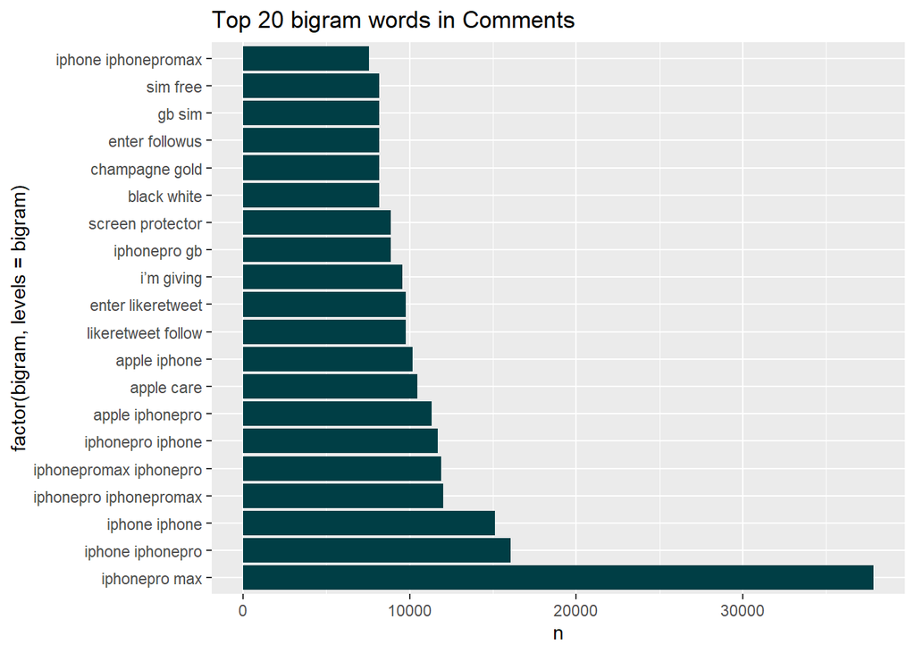

```r
bigram_united <- bigrams_filtered %>%
  unite(bigram, word1, word2, sep = " ")

bigram_counts <- bigram_united %>%
  dplyr::count(bigram, sort = TRUE)

bigram_counts %>% arrange(desc(n))%>% head(20)%>%ggplot(aes(x=factor(bigram,levels=bigram),y=n))+geom_bar(stat="identity",fill="#003E45")+labs(title="Top 20 bigram words in Comments")+coord_flip()
```

**12. Word correlations**

```r
rare <- cleaned_tokens %>%
  count(word) %>%
  filter(n<100) %>% #remove rare words
  # < 1000 reviews
  select(word) %>% distinct()

word_cor <- cleaned_tokens %>%
  filter(!word %in% rare$word) %>%
  widyr::pairwise_cor(word, Sno) %>%
  filter(!is.na(correlation),
         correlation > .25)
head(word_cor,5)
```

```
## # A tibble: 5 x 3
##   item1     item2     correlation
##   <chr>     <chr>           <dbl>
## 1 care      apple           0.335
## 2 either    apple           0.255
## 3 champagne apple           0.261
## 4 followus  apple           0.261
## 5 max       iphonepro       0.426
```

**Visualizing word correlation:**

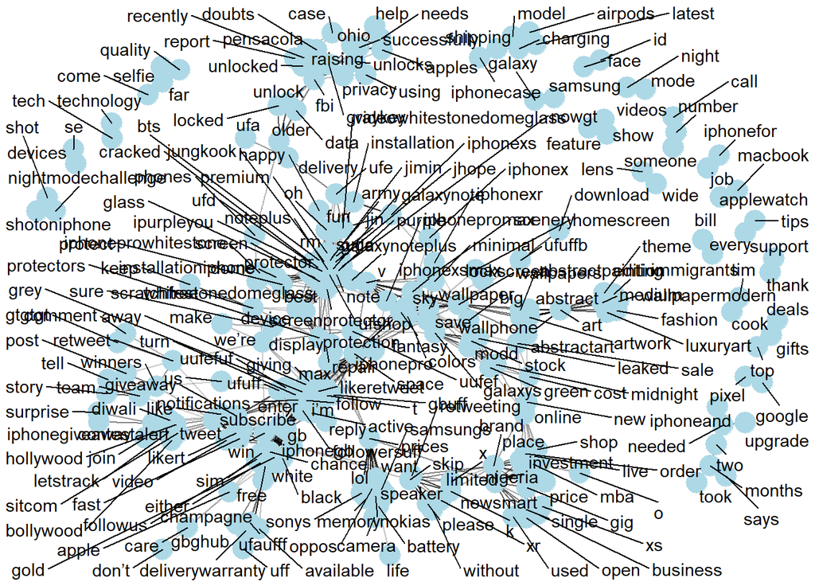

```r
word_cor %>%
  graph_from_data_frame() %>%
  ggraph(layout = "fr") +
  geom_edge_link(aes(edge_alpha = correlation), show.legend = FALSE) +
  geom_node_point(color = "lightblue", size = 6) +
  geom_node_text(aes(label = name), repel = TRUE) +
  theme_void()
```

**13. Document Term Matrix**

tf-idf is Term Frequency and Inverse document frequency. Using this, We can see the repititon of a term in a document and as compared to overall frequency of document.

```r
word_counts_by_SNo <- cleaned_tokens %>%
  group_by(Sno) %>%
  dplyr::count(word, sort = TRUE)
word_counts_by_SNo
```

```
## # A tibble: 230,808 x 3
## # Groups:   Sno [22,894]
##      Sno word               n
##    <int> <chr>          <int>
##  1  3317 iphonegiveaway    14
##  2  3319 iphonegiveaway    14
##  3  3318 iphonegiveaway    13
##  4  3320 iphonegiveaway    13
##  5 23616 iphone            10
##  6 23617 iphone            10
##  7 17533 gbghub             9
##  8 17537 gbghub             9
##  9 17541 gbghub             9
## 10 19062 gbghub             9
## # ... with 230,798 more rows
```

```r
review_dtm <- word_counts_by_SNo %>%
  cast_dtm(Sno, word, n)
```

**14. Displaying the top tf-idf in the document**

```r
tfidf <- word_counts_by_SNo %>%
  bind_tf_idf(word, Sno, n)

top_tfidf <- tfidf %>%
  group_by(Sno) %>%
  arrange(desc(tf_idf)) %>%
  top_n(3) %>% ungroup() %>%
  arrange(Sno, -tf_idf)
head(top_tfidf,10)
```

```
## # A tibble: 10 x 6
##      Sno word               n     tf   idf tf_idf
##    <int> <chr>          <int>  <dbl> <dbl>  <dbl>
##  1     1 panel              1 0.111   7.64  0.849
##  2     1 leading            1 0.111   7.27  0.807
##  3     1 increase           1 0.111   7.21  0.801
##  4     2 capture            2 0.0870  6.40  0.557
##  5     2 video              3 0.130   3.81  0.497
##  6     2 checking           1 0.0435  7.55  0.328
##  7     3 setup              1 0.0833  7.64  0.637
##  8     3 iphoneunboxing     1 0.0833  7.27  0.606
##  9     3 sweet              1 0.0833  6.99  0.583
## 10     4 macbook            2 0.111   5.22  0.580
```

**15. Now creating a 5 topic LDA model**

```r
lda5 <- LDA(review_dtm, k = 5, control = list(seed = 1234))
terms(lda5, 10)
```

```
##       Topic 1  Topic 2     Topic 3     Topic 4       Topic 5
##  [1,] "iphone" "apple"     "iphone"    "max"         "iphone"
##  [2,] "phone"  "care"      "apple"     "iphonepro"   "iphonepromax"
##  [3,] "just"   "iphonepro" "iphonepro" "iphone"      "iphonepro"
##  [4,] "get"    "free"      "new"       "gb"          "screen"
##  [5,] "new"    "fbi"       "camera"    "follow"      "wallpapers"
##  [6,] "like"   "gb"        "pro"       "enter"       "best"
##  [7,] "can"    "win"       "ios"       "giveaway"    "wallpaper"
##  [8,] "got"    "black"     "uf"        "likeretweet" "v"
##  [9,] "one"    "white"     "case"      "away"        "glass"
## [10,] "s"      "chance"    "tech"      "giving"      "iphonexsmax"
```